# Assignment 7

Jiaming Xu

# Q1:

### 1. Collecting data:

```r
library(tidyverse)
library(neuralnet)
```

1. Read xls file using read_xls and change column names.
2. create normalize function.
3. I used sapply instead of lapply since the input is a neat data frame. Convert results as a tibble.
4. Split normalized data into a training and a testing data sets using randomly assigning method.

```r
set.seed(7)
df <- readxl::read_xls("Concrete_Data.xls")
colnames(df) <- c('cement','slag','ash','water','superplastic','coarseagg','fineagg','age','strength')

normalize <- function(x) {
  return( (x - min(x) ) / (max(x) - min(x)))
}

concrete_norm <- sapply(df, normalize) %>% as_tibble()

summary(concrete_norm$strength)
```

```
##    Min. 1st Qu.  Median    Mean 3rd Qu.    Max.
##  0.0000  0.2663  0.4000  0.4172  0.5457  1.0000
```

```r
summary(df$strength)
```

```
##    Min. 1st Qu.  Median    Mean 3rd Qu.    Max.
##   2.332  23.707  34.443  35.818  46.136  82.599
```

```r
trainidx <- sample(1:nrow(concrete_norm), 0.7*nrow(concrete_norm))
concrete_train <- concrete_norm[trainidx, ]
concrete_test <- concrete_norm[-trainidx, ]
```

### 3. training a model

1. train model and plot ANN.

```r
set.seed(1)
concrete_model <- neuralnet(strength ~ ., data = concrete_train)
plot(concrete_model)
```

[output not shown]

### 4. Evaluating performance

1. Use compute (instead of prediction or augment) for prediction.
2. Performance is measured by correlation between prediction and target values in test dataset. Correlation is relatively the same as it in the testbook.

```r
set.seed(12345)
model_results <- compute(concrete_model, concrete_test[1:8])
predicted_strength<- model_results$net.result
cor(predicted_strength, concrete_test$strength )
```

```
##           [,1]
## [1,] 0.8263917
```

### 5. Improving performance

Also, the correlation between prediction and target increases to 0.934 now.

```r
set.seed(12345)
concrete_model2 <- neuralnet(strength ~ . , data = concrete_train, hidden = 5)
plot(concrete_model2)
model_results2 <- compute(concrete_model2, concrete_test[1:8])
predicted_strength2 <- model_results2$net.result
cor(predicted_strength2, concrete_test$strength)
```

[output not shown]

```
##           [,1]
## [1,] 0.9337743
```

One step further, I did two hidden layers with 5 nodes each. The prediction accuracy wasn’t improved too much.

```r
set.seed(12345)
concrete_model3 <- neuralnet(strength ~ . , data = concrete_train, hidden = c(5,5))
plot(concrete_model3)
model_results3 <- compute(concrete_model3, concrete_test[1:8])
predicted_strength3 <- model_results3$net.result
cor(predicted_strength3, concrete_test$strength)
```

[output not shown]

```
##           [,1]
## [1,] 0.9447005
```

# Question 2 - SVM

Support Vector Machine (SVM) is a robust machine learning algorithm that can be applied for both numeric and classification prediction. Idea of SVM are not complex, but there are many tricky techniques to make it work better.

Here, we only learned how to use it in a proper way.

### 1. collecting data. 2. exploring data.

1. Find the column names of dataset on website. Read html as raw, find specific node, then save plain text, finding colnames using regex.
2. Change lettr column as factor to perform SVM.

```r
library(rvest)
library(httr)

url <- "https://archive.ics.uci.edu/ml/datasets/letter+recognition"
html_raw <- read_html(url)
text <- html_raw %>%
  html_nodes(xpath = '//p[@class="normal"]') %>%
  html_text2()
col.names <- str_match_all(text[22], "\\d+\\. (.*?) ")[[1]][,2]
df <- read_csv('letter-recognition.csv', col_names = col.names)
df$lettr <- as.factor(df$lettr)
```

3. Data set is divided into a train and a test part with 0.7 and 0.3 ratio randomly.

```r
set.seed(7)
train_idx <- sample(1:nrow(df), 0.7*nrow(df))
letters_train <- df[train_idx, ]
letters_test  <- df[-train_idx, ]
```

### 3. training a model on data

```r
library(kernlab)
letter_classifier <- ksvm(lettr ~ ., data = letters_train,
                            kernel = "vanilladot")
letter_classifier
```

```
## Support Vector Machine object of class "ksvm"
##
## SV type: C-svc  (classification)
##  parameter : cost C = 1
##
## Linear (vanilla) kernel function.
##
## Number of Support Vectors : 6347
##
## Objective Function Value : -15.7115 -16.9735 -30.0733 -6.1765 -10.2333 -32.4003 -54.1105 -16.2949 -54.6265 -32.1332 -13.032 -31.4328 -31.3564 -48.8037 -13.5059 -38.33 -33.0753 -15.9375 -13.4369 -33.7303 -26.9259 -8.0867 -11.3666 -30.6693 -11.8435 -6.663 -127.0164 -43.7419 -53.9918 -96.0391 -147.6…
## Training error : 0.130214
```

### 4. performance of model.

```r
letter_predictions <- predict(letter_classifier, letters_test)
agreement <- letter_predictions == letters_test$lettr
table(agreement)
```

```
## agreement
## FALSE  TRUE
##   869  5131
```

```r
prop.table(table(agreement))
```

```
## agreement
##     FALSE      TRUE
## 0.1448333 0.8551667
```

### 5. Improving performance

```r
letter_classifier_rbf <- ksvm(lettr ~ ., data = letters_train,
                                kernel = "rbfdot")
letter_predictions_rbf <- predict(letter_classifier_rbf,
                                    letters_test)
agreement_rbf <- letter_predictions_rbf == letters_test$lettr
table(agreement_rbf)
```

```
## agreement_rbf
## FALSE  TRUE
##   410  5590
```

```r
prop.table(table(agreement_rbf))
```

```
## agreement_rbf
##      FALSE       TRUE
## 0.06833333 0.93166667
```

Small summary:

ANN and SVM are two complicated algorithm for machine learning among what we’ve learned so far. The details of them are beyond the scope of this course, and the algorithms are hard to remember for a long time for myself. Therefore, I’ll just use these tools instead of digging into them. Just like we use our cell phone everyday but no one wants to figure out how and why it works as it is.

# Question 3 - Finding Patterns – Market Basket Analysis Using Association Rules.

Groceries data set is not ordinary as we processed before which can directly import as a tibble. Instead, it looks like a NOSQL. Item types are placed in curly brackers.

### 1. Collecting data.

Groceries is an itemMatrix in sparse format, with 9835 transactions and 169 items might purchased. 1 if purchased, 0 otherwise.

Names of most frequent items and values are listed. Milk exists in 2513 / 9835 * 100% = 25% of all transactions.

Statistics info is listed at last, items in each transaction ranging from 1 to 32.

```r
library(arules)
data(Groceries)
summary(Groceries)
```

```
## transactions as itemMatrix in sparse format with
##  9835 rows (elements/itemsets/transactions) and
##  169 columns (items) and a density of 0.02609146
##
## most frequent items:
##       whole milk other vegetables       rolls/buns             soda
##             2513             1903             1809             1715
##           yogurt          (Other)
##             1372            34055
##
## element (itemset/transaction) length distribution:
## sizes
##    1    2    3    4    5    6    7    8    9   10   11   12   13   14   15   16
## 2159 1643 1299 1005  855  645  545  438  350  246  182  117   78   77   55   46
##   17   18   19   20   21   22   23   24   26   27   28   29   32
##   29   14   14    9   11    4    6    1    1    1    1    3    1
##
##    Min. 1st Qu.  Median    Mean 3rd Qu.    Max.
##   1.000   2.000   3.000   4.409   6.000  32.000
##
## includes extended item information - examples:
##        labels  level2           level1
## 1 frankfurter sausage meat and sausage
## 2     sausage sausage meat and sausage
## 3  liver loaf sausage meat and sausage
```

Detail of transactions can be extracted by inspect function. Item frequency can be extracted by itemFrequency function.

```r
inspect(Groceries[1:5])
```

```
##     items
## [1] {citrus fruit,
##      semi-finished bread,
##      margarine,
##      ready soups}
## [2] {tropical fruit,
##      yogurt,
##      coffee}
## [3] {whole milk}
## [4] {pip fruit,
##      yogurt,
##      cream cheese ,
##      meat spreads}
## [5] {other vegetables,
##      whole milk,
##      condensed milk,
##      long life bakery product}
```

```r
itemFrequency(Groceries[, 1:3])
```

```
## frankfurter     sausage  liver loaf
## 0.058973055 0.093950178 0.005083884
```

Items with frequency more than 10% are plotted in the below by specifying support argument to 0.1.

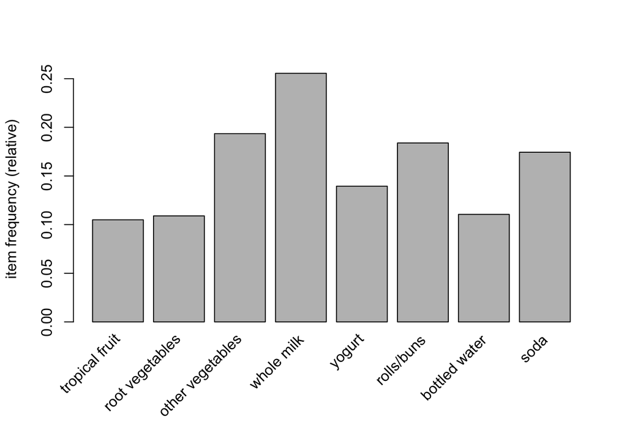

```r
itemFrequencyPlot(Groceries, support=0.1)
```

In another way, top 20 frequency can be plotted by speficying topN argument. top 20 items are commonly purchased in my daily life except beer and newspapers. Therefore, they’re resonable in my perspective.

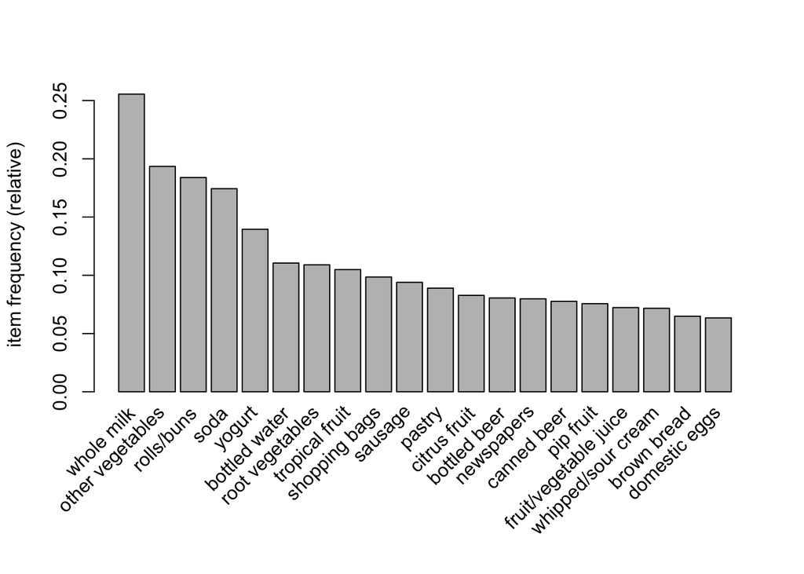

```r
itemFrequencyPlot(Groceries, topN = 20)
```

It can also be plotted as a scatter plot, y axis as transactions and x axis as items. Also sample function can be used to randomly shuffle the data.

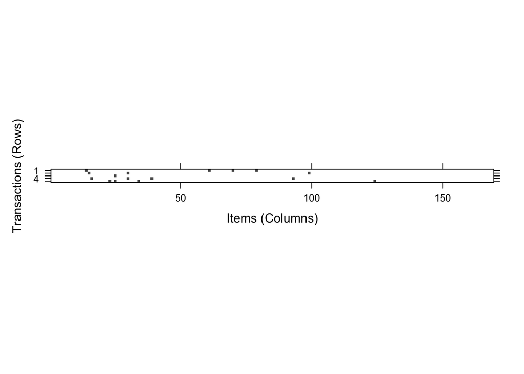

```r
image(Groceries[1:5])
```

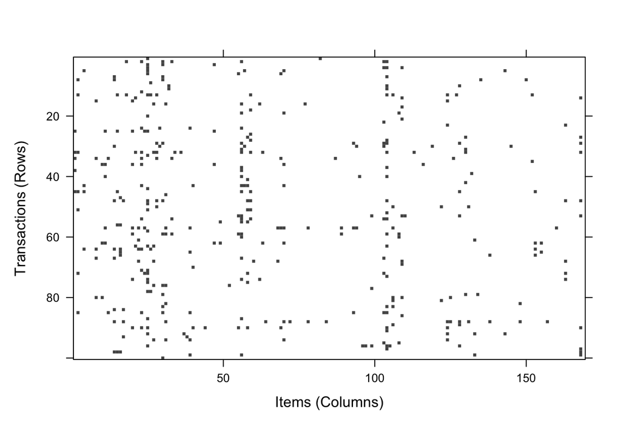

```r
image(sample(Groceries, 100))
```

### 3. Training a model on the data

Zero rules using default values - support = 0.1, confidence = 0.8. We need to adjust these two values in order to generate useful rules.

```r
apriori(Groceries)
```

```
## Apriori
##
## Parameter specification:
##  confidence minval smax arem  aval originalSupport maxtime support minlen
##         0.8    0.1    1 none FALSE            TRUE       5     0.1      1
##  maxlen target  ext
##      10  rules TRUE
##
## Algorithmic control:
##  filter tree heap memopt load sort verbose
##     0.1 TRUE TRUE  FALSE TRUE    2    TRUE
##
## Absolute minimum support count: 983
##
## set item appearances ...[0 item(s)] done [0.00s].
## set transactions ...[169 item(s), 9835 transaction(s)] done [0.00s].
## sorting and recoding items ... [8 item(s)] done [0.00s].
## creating transaction tree ... done [0.00s].
## checking subsets of size 1 2 done [0.00s].
## writing ... [0 rule(s)] done [0.00s].
## creating S4 object  ... done [0.00s].
```

```
## set of 0 rules
```

```r
set.seed(7)
groceryrules <- apriori(Groceries,
                        parameter = list(support = 0.005,
                                         confidence = 0.25,
                                         minlen = 2))
```

```
## Apriori
##
## Parameter specification:
##  confidence minval smax arem  aval originalSupport maxtime support minlen
##        0.25    0.1    1 none FALSE            TRUE       5   0.005      2
##  maxlen target  ext
##      10  rules TRUE
##
## Algorithmic control:
##  filter tree heap memopt load sort verbose
##     0.1 TRUE TRUE  FALSE TRUE    2    TRUE
##
## Absolute minimum support count: 49
##
## set item appearances ...[0 item(s)] done [0.00s].
## set transactions ...[169 item(s), 9835 transaction(s)] done [0.00s].
## sorting and recoding items ... [120 item(s)] done [0.00s].
## creating transaction tree ... done [0.00s].
## checking subsets of size 1 2 3 4 done [0.00s].
## writing ... [662 rule(s)] done [0.00s].
## creating S4 object  ... done [0.00s].
```

### 4. Evaluating performance

There are more information arules providing than textbook, converage and count are two new parameters for example.

```r
summary(groceryrules)
```

```
## set of 662 rules
##
## rule length distribution (lhs + rhs):sizes
##   2   3   4
## 161 457  44
##
##    Min. 1st Qu.  Median    Mean 3rd Qu.    Max.
##   2.000   3.000   3.000   2.823   3.000   4.000
##
## summary of quality measures:
##     support           confidence        coverage             lift
##  Min.   :0.005084   Min.   :0.2500   Min.   :0.008134   Min.   :0.9932
##  1st Qu.:0.005821   1st Qu.:0.2968   1st Qu.:0.015074   1st Qu.:1.6560
##  Median :0.007321   Median :0.3622   Median :0.020742   Median :1.9873
##  Mean   :0.009722   Mean   :0.3848   Mean   :0.027278   Mean   :2.0908
##  3rd Qu.:0.010142   3rd Qu.:0.4559   3rd Qu.:0.029893   3rd Qu.:2.4294
##  Max.   :0.074835   Max.   :0.7000   Max.   :0.255516   Max.   :4.0855
##      count
##  Min.   : 50.00
##  1st Qu.: 57.25
##  Median : 72.00
##  Mean   : 95.61
##  3rd Qu.: 99.75
##  Max.   :736.00
##
## mining info:
##       data ntransactions support confidence
##  Groceries          9835   0.005       0.25
##                                                                                         call
##  apriori(data = Groceries, parameter = list(support = 0.005, confidence = 0.25, minlen = 2))
```

Specific rules can be viewed using inspect function: First three rules are {cake bar} -> {whole milk}, {dishes} -> {oter vegetables}, and {dishes} -> {whole milk}. Among these three, my point is dishes and whole milk is not relational except these two items are short in kitchen. In addition, lift of {dishes} -> {whole milk} is 1.176, less than other two rules. That also makes sense it’s less important from the view of algorithm.

```r
inspect(groceryrules[1:3])
```

```
##     lhs           rhs                support     confidence coverage   lift
## [1] {cake bar} => {whole milk}       0.005592272 0.4230769  0.01321810 1.655775
## [2] {dishes}   => {other vegetables} 0.005998983 0.3410405  0.01759024 1.762550
## [3] {dishes}   => {whole milk}       0.005287239 0.3005780  0.01759024 1.176357
##     count
## [1] 55
## [2] 59
## [3] 52
```

### 5. Improving performance

We can only use rules with top lift values which infers they’re more important.

```r
inspect( sort( groceryrules, by = 'lift')[1:5])
```

```
##     lhs                    rhs                      support confidence   coverage     lift count
## [1] {citrus fruit,
##      other vegetables,
##      whole milk}        => {root vegetables}    0.005795628  0.4453125 0.01301474 4.085493    57
## [2] {other vegetables,
##      butter}            => {whipped/sour cream} 0.005795628  0.2893401 0.02003050 4.036397    57
## [3] {herbs}             => {root vegetables}    0.007015760  0.4312500 0.01626843 3.956477    69
## [4] {citrus fruit,
##      pip fruit}         => {tropical fruit}     0.005592272  0.4044118 0.01382816 3.854060    55
## [5] {berries}           => {whipped/sour cream} 0.009049314  0.2721713 0.03324860 3.796886    89
```

Another way to do is taking subsets of association rules. This method is more like a further step to make results sorted by lift more accurate and covered. Items inside subset function includes both lhs and rhs items, we can only extract lhs or rhs if we want.

```r
berryrules <- subset(groceryrules, items %in% "berries")
inspect(berryrules)
```

```
##     lhs          rhs                  support     confidence coverage  lift
## [1] {berries} => {whipped/sour cream} 0.009049314 0.2721713  0.0332486 3.796886
## [2] {berries} => {yogurt}             0.010574479 0.3180428  0.0332486 2.279848
## [3] {berries} => {other vegetables}   0.010269446 0.3088685  0.0332486 1.596280
## [4] {berries} => {whole milk}         0.011794611 0.3547401  0.0332486 1.388328
##     count
## [1]  89
## [2] 104
## [3] 101
## [4] 116
```

Summary for Apriori:

Apriori is a way to find relationship between two items by only knowing their frequency, then propose how possible one get involved by the other one. It’s very useful while we’re trying to figure out what’s the possible causation of one variable.